# Homework 3: Pipeline of a predictive model

## Group members

Adrián Correa Cruz - 74853939W  
Azul María García - Y9889243Q  
Nuria María Haba Díaz - 79030458C  
José Luis Puente Bodoque - 79038387Z

1. Wine Quality Dataset
2. Data profiling with Pandas
3. Exploratory data analysis  
   3.1 Unbalanced dataset  
   3.2 Skewness and kurtosis  
   3.3 Correlation among features
4. Training of multi-class classification models and evaluation of results  
   4.1 Support Vector Machine (SVM))  
   4.2 k-nearest neighbors (k-NN))  
   4.3 Random Forest classifier  
   4.4 Partial conclusion
5. Over-sampling technique: SMOT  
   5.1 Brief theoretical explanation  
   5.2 Dataset transformation into a new balanced one
6. Re-training of multi-class models and evaluation of results  
   6.1 Model selection: stratified shuffle split  
   6.2 Pipeline: Support Vector Machine  
   6.3 Pipeline: k-NN  
   6.4 Pipeline: Random Forest
7. Table of accuracies
8. Summary and conclusions

## Wine Quality Dataset

In this homework we are working on the Wine Quality dataset, downloaded from the [UCI repository](https://archive.ics.uci.edu/ml/datasets/wine+quality). Authors: P. Cortez, A. Cerdeira, F. Almeida, T. Matos and J. Reis.

The dataset actually contains two datasets corresponding to the two variants of red and white wine of the Portuguese "Vinho Verde". We will working on the **red wine dataset** since the limit of examples for the assessment is set to 5000.

The red wines dataset contains 12 features from which 11 are the chemical properties of the wine and the remaining is the quality awarded by an expert taster. The **aim of this notebook** thus is **to train a model that predicts the quality of a red wine** and, as we'll see then, **deal with the unbalancing of the number of examples per class**.

## Data profiling with Pandas

The first thing is to load the list of modules we have used in this notebook.

```python
%matplotlib inline
import pandas as pd # To read the dataset into a DataFrame object that provides not just values but the labels as well
import numpy as np # To work with n-dimensional arrays
import seaborn as sns # Visualization
from sklearn.preprocessing import StandardScaler # To improve numerical stability during the fitting process
import matplotlib.pyplot as plt # Visualization
from imblearn.over_sampling import SMOTE # An over-sampling technique to battle against unbalanced dataset
from sklearn.neighbors import NearestNeighbors # The algorithm that SMOTE runs under the hood
from sklearn.model_selection import train_test_split # To split the dataset into a training and test set
from sklearn.model_selection import StratifiedShuffleSplit # An alternative way of doing the previous splitting
from sklearn.model_selection import GridSearchCV # Cross-validator as strategy of grid search
from sklearn.pipeline import Pipeline # To encapsulate the preprocessing process and instatiation of the estimator
from sklearn.svm import SVC # Support Vector Machine classifier
from sklearn.metrics import classification_report # Performance metrics such as accuracy, precision, recall and F1 score
from sklearn.metrics import confusion_matrix, ConfusionMatrixDisplay # Confusion matrix
from sklearn.neighbors import KNeighborsClassifier # k-NN
from sklearn.ensemble import RandomForestClassifier # Random Forest classifier
```

Now we read the dataset. Although it does not carry a .csv extension, the file content is a semicolon-separated value, so we may use the following `Pandas.DataFrame` method:

```python
df = pd.read_csv('data/winequality-red.csv', delimiter=';')
```

Let's see some information about the data

```python
df.info()
```

```
<class 'pandas.core.frame.DataFrame'>
RangeIndex: 1599 entries, 0 to 1598
Data columns (total 12 columns):
 #   Column                Non-Null Count  Dtype
---  ------                --------------  -----
 0   fixed acidity         1599 non-null   float64
 1   volatile acidity      1599 non-null   float64
 2   citric acid           1599 non-null   float64
 3   residual sugar        1599 non-null   float64
 4   chlorides             1599 non-null   float64
 5   free sulfur dioxide   1599 non-null   float64
 6   total sulfur dioxide  1599 non-null   float64
 7   density               1599 non-null   float64
 8   pH                    1599 non-null   float64
 9   sulphates             1599 non-null   float64
 10  alcohol               1599 non-null   float64
 11  quality               1599 non-null   int64
dtypes: float64(11), int64(1)
memory usage: 150.0 KB
```

The dataset has **1599 examples** and **11 real-value features**. The quality column is the feature we want to predict, so it stands for the **labels**, which are stored as integer values but are actually natural number. We are lucky that there are not any null value.

```python
df.head()
```

|  | fixed acidity | volatile acidity | citric acid | residual sugar | chlorides | free sulfur dioxide | total sulfur dioxide | density | pH | sulphates | alcohol | quality |
| --- | --- | --- | --- | --- | --- | --- | --- | --- | --- | --- | --- | --- |
| 0 | 7.4 | 0.70 | 0.00 | 1.9 | 0.076 | 11.0 | 34.0 | 0.9978 | 3.51 | 0.56 | 9.4 | 5 |
| 1 | 7.8 | 0.88 | 0.00 | 2.6 | 0.098 | 25.0 | 67.0 | 0.9968 | 3.20 | 0.68 | 9.8 | 5 |
| 2 | 7.8 | 0.76 | 0.04 | 2.3 | 0.092 | 15.0 | 54.0 | 0.9970 | 3.26 | 0.65 | 9.8 | 5 |
| 3 | 11.2 | 0.28 | 0.56 | 1.9 | 0.075 | 17.0 | 60.0 | 0.9980 | 3.16 | 0.58 | 9.8 | 6 |
| 4 | 7.4 | 0.70 | 0.00 | 1.9 | 0.076 | 11.0 | 34.0 | 0.9978 | 3.51 | 0.56 | 9.4 | 5 |

Now we check whether there are values out of range or not.

```python
df.describe()
```

|  | fixed acidity | volatile acidity | citric acid | residual sugar | chlorides | free sulfur dioxide | total sulfur dioxide | density | pH | sulphates | alcohol | quality |
| --- | --- | --- | --- | --- | --- | --- | --- | --- | --- | --- | --- | --- |
| count | 1599.000000 | 1599.000000 | 1599.000000 | 1599.000000 | 1599.000000 | 1599.000000 | 1599.000000 | 1599.000000 | 1599.000000 | 1599.000000 | 1599.000000 | 1599.000000 |
| mean | 8.319637 | 0.527821 | 0.270976 | 2.538806 | 0.087467 | 15.874922 | 46.467792 | 0.996747 | 3.311113 | 0.658149 | 10.422983 | 5.636023 |
| std | 1.741096 | 0.179060 | 0.194801 | 1.409928 | 0.047065 | 10.460157 | 32.895324 | 0.001887 | 0.154386 | 0.169507 | 1.065668 | 0.807569 |
| min | 4.600000 | 0.120000 | 0.000000 | 0.900000 | 0.012000 | 1.000000 | 6.000000 | 0.990070 | 2.740000 | 0.330000 | 8.400000 | 3.000000 |
| 25% | 7.100000 | 0.390000 | 0.090000 | 1.900000 | 0.070000 | 7.000000 | 22.000000 | 0.995600 | 3.210000 | 0.550000 | 9.500000 | 5.000000 |
| 50% | 7.900000 | 0.520000 | 0.260000 | 2.200000 | 0.079000 | 14.000000 | 38.000000 | 0.996750 | 3.310000 | 0.620000 | 10.200000 | 6.000000 |
| 75% | 9.200000 | 0.640000 | 0.420000 | 2.600000 | 0.090000 | 21.000000 | 62.000000 | 0.997835 | 3.400000 | 0.730000 | 11.100000 | 6.000000 |
| max | 15.900000 | 1.580000 | 1.000000 | 15.500000 | 0.611000 | 72.000000 | 289.000000 | 1.003690 | 4.010000 | 2.000000 | 14.900000 | 8.000000 |

```python
df.isna().sum()
```

```
fixed acidity           0
volatile acidity        0
citric acid             0
residual sugar          0
chlorides               0
free sulfur dioxide     0
total sulfur dioxide    0
density                 0
pH                      0
sulphates               0
alcohol                 0
quality                 0
dtype: int64
```

Okay, the dataset is clean!

## Exploratory data analysis

### Unbalanced dataset

At the UCI repository, they warns us about the classes are not balanced (e.g. there are many more normal wines than excellent or poor ones). So let's check on a bar plot how many examples per class there are.

```python
frequency = df['quality'].value_counts()
print(frequency)
```

```
5    681
6    638
7    199
4     53
8     18
3     10
Name: quality, dtype: int64
```

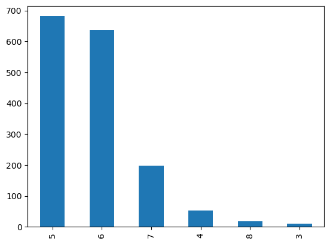

```python
frequency.plot(kind='bar')
```

The number of examples is not uniformly distributed among the 6 classes of quality. This means that an hypothetical predicting model would generalize correctly most of the examples (that is, the normal wines, those whose label corresponds to quality 7, 6 and 5), but worse the minority ones, those whose quality is either excellent (that is, 8) or poor (that is, 4 or 3).

### Skewness and kurtosis

Let's check the shape of the distributions of probability of every feature.

```
array([[<Axes: title={'center': 'fixed acidity'}>,
        <Axes: title={'center': 'volatile acidity'}>,
        <Axes: title={'center': 'citric acid'}>],
       [<Axes: title={'center': 'residual sugar'}>,
        <Axes: title={'center': 'chlorides'}>,
        <Axes: title={'center': 'free sulfur dioxide'}>],
       [<Axes: title={'center': 'total sulfur dioxide'}>,
        <Axes: title={'center': 'density'}>,
        <Axes: title={'center': 'pH'}>],
       [<Axes: title={'center': 'sulphates'}>,
        <Axes: title={'center': 'alcohol'}>,
        <Axes: title={'center': 'quality'}>]], dtype=object)
```

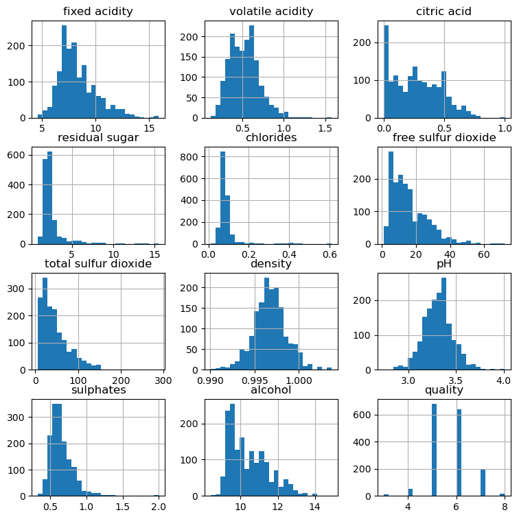

```python
df.hist(bins=25,figsize=(9,9))
```

Let's calculate skewness ($s$). Its interpretation is:

- $s > 0$ means asymmetric or biased to the right or positive
- $s = 0$ means symmetric or unbiased
- $s < 0$ mean asymmetric or biased to the left or negative

Bulmer (1979) proposed the following rule of thumb:

- $s < |0.5|$ is a small skewness
- $0.5 \leq |s| \leq 1.0$ is a moderate skewness
- $|s| \gt 1$ is heavily skewness

```python
df.skew().sort_values(ascending=False)
```

```
chlorides               5.680347
residual sugar          4.540655
sulphates               2.428672
total sulfur dioxide    1.515531
free sulfur dioxide     1.250567
fixed acidity           0.982751
alcohol                 0.860829
volatile acidity        0.671593
citric acid             0.318337
quality                 0.217802
pH                      0.193683
density                 0.071288
dtype: float64
```

Let's calculate kurtosis ($k$) according to Fisher's definition of Pandas library. Its interpretation is:

- $k < 0$ (platykurtic) means less sharpness (*apuntamiento*) than normal distribution
- $k = 0$ (mesokurtic) means same sharpness than normal distribution
- $k > 0$ (leptokurtic) means more sharpness than normal distribution

```python
df.kurtosis().sort_values(ascending=False) # Fisher's kurtosis
```

```
chlorides               41.715787
residual sugar          28.617595
sulphates               11.720251
total sulfur dioxide     3.809824
free sulfur dioxide      2.023562
volatile acidity         1.225542
fixed acidity            1.132143
density                  0.934079
pH                       0.806943
quality                  0.296708
alcohol                  0.200029
citric acid             -0.788998
dtype: float64
```

Almost all features are right (positively) skewed, asymmetrics and leptokurtics.

- Since the data is right skewed, it means that is has a higher number of data points (or examples) having low values. So when we train the model on this training data, it will perform better at predicting the quality of wines with low values compared to those with higher feature values. Skewness also tells us about the direction of outliers: **most of outliers are present on the right side of the distribution**.
- Since the distributions are leptokurtics, it means that the model will predict better the values at the center than those at the tails. Kurtosis tells us about the frequency of outliers: **the features with the most amount of outliers are chlorides, residual sugar and sulphates**.

### Correlation among features

Let's measure the correlation among each pair of features on a heat map

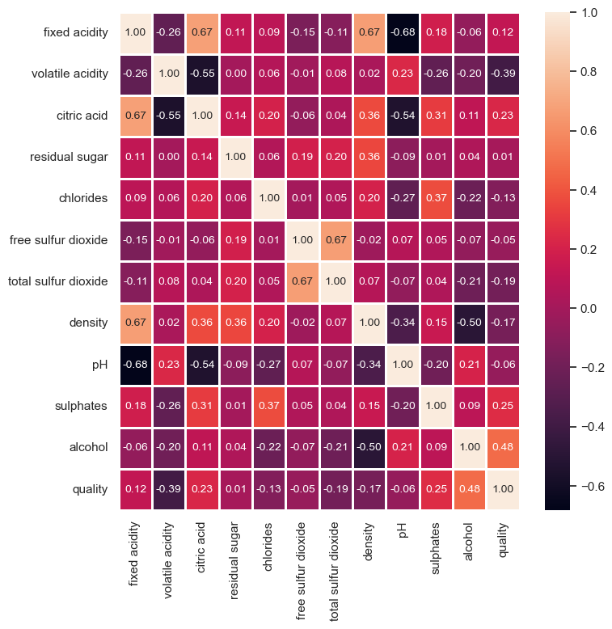

```python
sns.set(rc={'figure.figsize':(8,8)})
sns.heatmap(df.corr(), annot=True, fmt='.2f', linewidth=2, annot_kws={'fontsize':10})
```

It's proved that features with high correlation are more linearly dependant and hence have almost the same effect on the dependent variable (that feature we want to predict). So when two features have high correlation (positively or negatively), we can drop one of the two features. In this way the dataset becomes lighter. In our dataset there are no pair of features enoughly correlated so discarding a feature would not affect to the goodness of the prediction.

## Training of multi-class classification models and evaluation of results

Let's see how much accuracy we obtain from training a multi-class classification model on an unbalanced dataset and plenty of outliers. So the first is to obtain the examples and labels:

```python
examples = pd.read_csv('data/winequality-red.csv', delimiter=';', header=0)
labels = examples.pop('quality')
```

And split the data into training and test sets:

```python
X_train, X_test, y_train, y_test = train_test_split(examples,
                                                    labels,
                                                    test_size=0.20,
                                                    random_state=42)
```

```python
print(X_train.shape)
print(y_train.shape)
print(X_test.shape)
print(y_test.shape)
```

```
(1279, 11)
(1279,)
(320, 11)
(320,)
```

1279 examples to train the model and 320 examples to test it. The number of features associated to each label in training set is:

```python
print(y_train.value_counts())
```

```
5    551
6    506
7    157
4     43
8     13
3      9
Name: quality, dtype: int64
```

The number of features associated to each label in test set is:

```python
print(y_test.value_counts())
```

```
6    132
5    130
7     42
4     10
8      5
3      1
Name: quality, dtype: int64
```

Let's see this graphically:

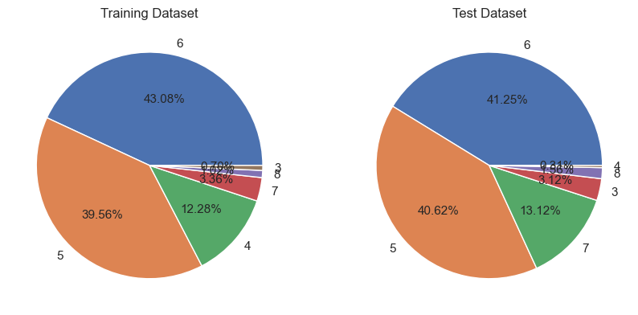

```python
plt.figure(figsize=(10,10))
plt.subplot(121)
plt.pie(y_train.value_counts(),labels=y_train.unique(),autopct = '%1.2f%%',shadow=False, textprops={'fontsize': 11})
plt.title('Training Dataset')

plt.subplot(122)
plt.pie(y_test.value_counts(),labels=y_test.unique(),autopct = '%1.2f%%', shadow=False, textprops={'fontsize': 11})
plt.title('Test Dataset')
```

As we can see the number of examples per class is very unbalanced so we can't expect good predictions on examples whose quality is excellent or poor.

### Support Vector Machine (SVM)

```python
# Parameters ranges
Cs = np.logspace(-5, 15, 10, base=2)
gammas = np.logspace(-15, 10, 8, base=2)

# Parameter grid
param_grid = {'svc__C':Cs,
              'svc__gamma':gammas}

# Make a pipeline to a more efficient preprocessing a fitting process
pipeline = Pipeline(steps=[('scaler', StandardScaler()),('svc', SVC(kernel='rbf'))])

grid_search_cv = GridSearchCV(estimator=pipeline,
                  param_grid=param_grid,
                  scoring='accuracy',
                  verbose=1,
                  n_jobs=8)

# Perform the grid search
grid_search_cv.fit(X_train, y_train)
```

```
Fitting 5 folds for each of 80 candidates, totalling 400 fits
```

```
GridSearchCV(estimator=Pipeline(steps=[('scaler', StandardScaler()),
                                       ('svc', SVC())]),
             n_jobs=8,
             param_grid={'svc__C': array([3.12500000e-02, 1.45816130e-01, 6.80395000e-01, 3.17480210e+00,
       1.48139954e+01, 6.91238233e+01, 3.22539789e+02, 1.50500812e+03,
       7.02254271e+03, 3.27680000e+04]),
                         'svc__gamma': array([3.05175781e-05, 3.62791574e-04, 4.31284966e-03, 5.12709598e-02,
       6.09506827e-01, 7.24578931e+00, 8.61376123e+01, 1.02400000e+03])},
             scoring='accuracy', verbose=1)
```

Let's check the parameters and metrics of the classifier:

```python
best_model = grid_search_cv.best_estimator_
best_acc = grid_search_cv.best_score_
best_C = grid_search_cv.best_params_['svc__C']
best_gamma = grid_search_cv.best_params_['svc__gamma']
```

```python
print("Best C = " + str(best_C))
print("Best gamma = " + str(best_gamma))
print("Best accuracy on train = " + str(best_acc))
print('Best accuracy on test = ' + str(best_model.score(X_test, y_test)))
```

```
Best C = 3.1748021039363996
Best gamma = 0.609506827102238
Best accuracy on train = 0.6505330882352942
Best accuracy on test = 0.665625
```

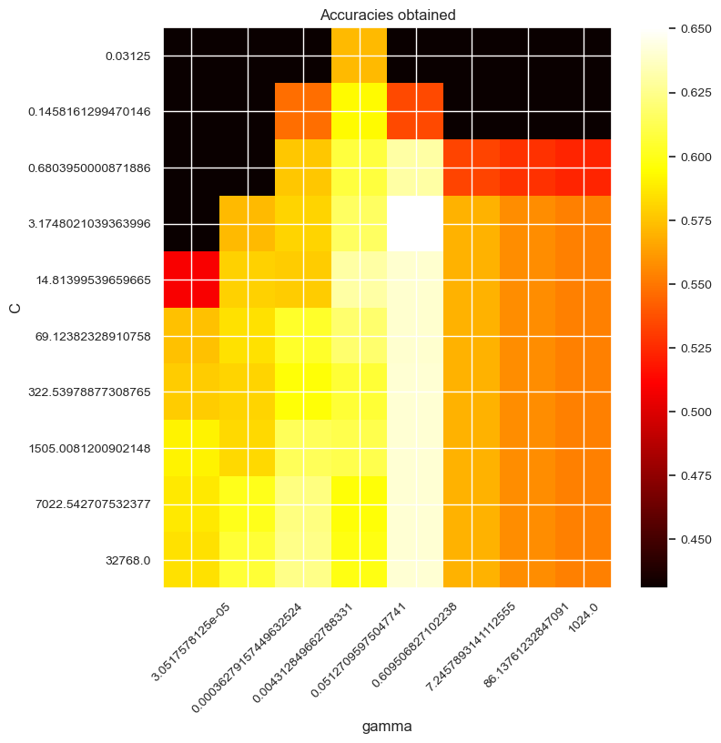

```python
vector_scores = grid_search_cv.cv_results_.get('mean_test_score')
grid_scores = np.reshape(vector_scores, (len(Cs), len(gammas)))

# New accuracies
plt.imshow(grid_scores, interpolation='nearest', cmap=plt.cm.hot)
plt.xlabel('gamma')
plt.ylabel('C')
plt.colorbar().ax.tick_params(labelsize=10)
plt.xticks(np.arange(len(gammas)), gammas, rotation=45, fontsize=10)
plt.yticks(np.arange(len(Cs)), Cs, fontsize=10)
plt.title('Accuracies obtained')
plt.show()
```

Accuracy on training set is pretty low and accuracy on test is also low and near the training one so it is a sign of underfitting.

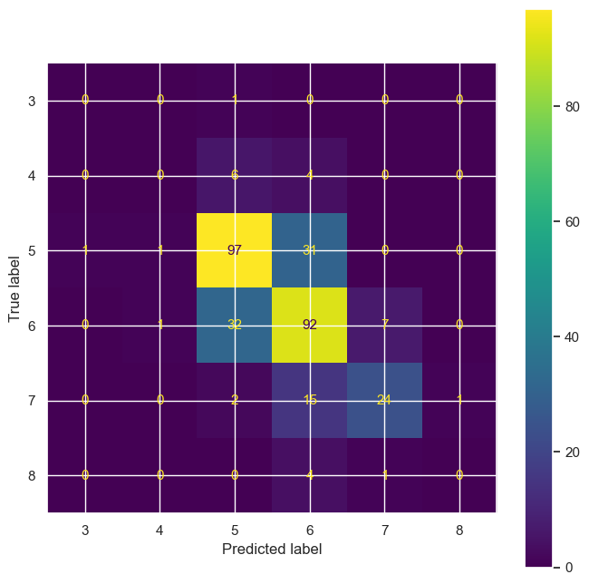

```python
from sklearn.metrics import confusion_matrix, ConfusionMatrixDisplay

y_pred = grid_search_cv.predict(X_test)
confusion_matrix = confusion_matrix(y_true=y_test, y_pred=y_pred, labels=grid_search_cv.classes_)
confusion_matrix_display = ConfusionMatrixDisplay(confusion_matrix=confusion_matrix, display_labels=grid_search_cv.classes_)
confusion_matrix_display.plot()
for text in confusion_matrix_display.text_.ravel():
    text.set_fontsize(11)
```

As expected, the model predicts normal wines better than poor and excellent wines.

### k-nearest neighbors (k-NN)

Let's try out a k-nearest neigbour classification model.

```python
# Grid of all posible candidate parameters to find the best ones
param_grid = {'knn__n_neighbors':[1,3,5,7,9,11,13],
              'knn__weights':['uniform', 'distance'],
              'knn__p':[2,3,4,5]}

# Another pipeline to encapsulate the fit and transform method and to compactate the code
# It's important to select at least two cores to speed up the training process
pipeline_2 = Pipeline(steps=[('scaler', StandardScaler()), ('knn', KNeighborsClassifier(n_jobs=4))])

grid_search_cv_2 = GridSearchCV(estimator=pipeline_2,
                      param_grid=param_grid,
                      scoring='accuracy',
                      cv=5, # 5-fold stratified CV
                      verbose=1,
                      n_jobs=8)

grid_search_cv_2.fit(X_train, y_train)

print('Best parameters=', grid_search_cv_2.best_params_)
print('Best accuracy on train=', grid_search_cv_2.best_score_)
print('Best accuracy on test=', grid_search_cv_2.score(X_test, y_test))
```

```
Fitting 5 folds for each of 56 candidates, totalling 280 fits
Best parameters= {'knn__n_neighbors': 13, 'knn__p': 2, 'knn__weights': 'distance'}
Best accuracy on train= 0.6685263480392157
Best accuracy on test= 0.678125
```

[figure not shown]

```python
from sklearn.metrics import confusion_matrix, ConfusionMatrixDisplay

confusion_matrix = confusion_matrix(y_true=y_test, y_pred=y_pred, labels=grid_search_cv_2.classes_)
confusion_matrix_display = ConfusionMatrixDisplay(confusion_matrix=confusion_matrix, display_labels=grid_search_cv_2.classes_)
confusion_matrix_display.plot()
for text in confusion_matrix_display.text_.ravel():
    text.set_fontsize(11)
```

### Random Forest classifier

Finally let's try out to train a random forest classification model.

```python
pipeline_random_forest = Pipeline(steps=[('scaler', StandardScaler()), ('rfc', RandomForestClassifier(n_estimators=200))])
pipeline_random_forest.fit(X_train, y_train)

# Accuracy on test test
acc_train = pipeline_random_forest.score(X_train, y_train)
acc_test = pipeline_random_forest.score(X_test, y_test)
print('Accuracy on train=', acc_train)
print('Accuracy on test=', acc_test)
```

```
Accuracy on train= 1.0
Accuracy on test= 0.6625
```

Overfitting is outrageous in this case.

### Partial conclusion

The accuracy is stuck at roughly 67 %. Tuning the hyperparameter doesn't help to increase the accuracy and drive into underfitting or overfitting models. Thus it doesn't depend on the classifier but on the dataset itself: the unbalancing of the dataset we show before on the skewed distributions for each feature. There aren't much enough examples to generalize correctly the accuracy over the minority examples. And the training processes deal minority examples like outliers, that is, tricky to classify properly.

A good way to deal with our unbalanced dataset consists of applying some resampling or over-sampling techniques, as we are going to see onwards.

## Over-sampling technique: SMOT

### Brief theoretical explanation

The **supervised synthetic minority oversampling technique** (SMOTE) consists of synthesizing (or populate artificially) elements for the minority class, based on those that already exist. It works randomly picking a point from the minority class and computing the k-nearest neighbors for this point. The synthetic points are added between the chosen point and its neighbors.

[figure not shown]

Source: https://www.kaggle.com/code/rafjaa/resampling-strategies-for-imbalanced-datasets

To implement SMOTE on our dataset we have used the module SMOTE of the library `imblearn.over_samples` (https://imbalanced-learn.org/stable/references/generated/imblearn.over_sampling.SMOTE.html).

```python
my_nearest_neighbors = NearestNeighbors(n_jobs=8) # desirable more than one core to speed up the over-sampling process
smote = SMOTE(sampling_strategy='not majority', k_neighbors=my_nearest_neighbors) # important the str 'not majority'
X_smote, y_smote = smote.fit_resample(examples, labels) # returns a Pandas.DataFrame object
```

We desire to transform leptokurtic distributions into platykurtic ones or, ideally, into uniform distributions. Now we must populate the minority classes and to not allow SMOTE object to populate any of the majority classes. We get this by using the string 'not majority' as value of the parameter `sampling_strategy`.

### Dataset transformation into a new balanced one

Let's check the number of instances per class now.

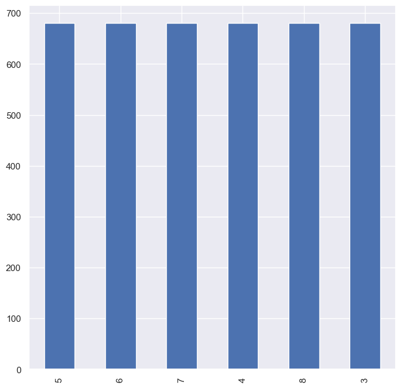

```python
frequency_smote = y_smote.value_counts()
frequency_smote.plot(kind='bar', figsize=(8,8))
```

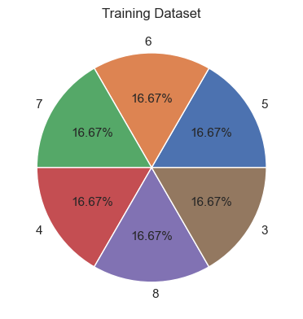

```python
from IPython.display import display

plt.figure(figsize=(10,10))
plt.subplot(121)
plt.pie(y_smote.value_counts(),labels=y_smote.unique(),autopct = '%1.2f%%',shadow=False, textprops={'fontsize': 11})
plt.title('Training Dataset')
```

Now all classes are equally represented.

## Re-training of multi-class models and evaluation of results

Let's train again our new balanced dataset with the same classification models than before.

### Model selection: stratified shuffle split

We split the dataset into training and test set by using the stratified, shuffle, then splitting strategy in order to conserve the same number of examples per class in both sets.

```python
stratified_shuffle_split = StratifiedShuffleSplit(n_splits=1, test_size=0.20, random_state=13)
for i, (train_index, test_index) in enumerate(stratified_shuffle_split.split(X_smote, y_smote)):

    X_train = X_smote.iloc[train_index]
    y_train = y_smote.iloc[train_index]

    X_test = X_smote.iloc[test_index,:]
    y_test = y_smote.iloc[test_index]

print(y_train.value_counts())
print(y_test.value_counts())
```

```
8    545
4    545
6    545
7    545
3    544
5    544
Name: quality, dtype: int64
5    137
3    137
6    136
8    136
7    136
4    136
Name: quality, dtype: int64
```

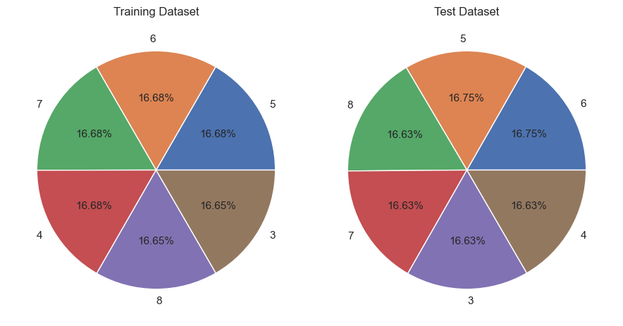

```python
plt.figure(figsize=(9,9))
plt.subplot(121)
plt.pie(y_train.value_counts(),labels=y_smote.unique(),autopct = '%1.2f%%',shadow=False, textprops={'fontsize': 11})
plt.title('Training Dataset')

plt.subplot(122)
plt.pie(y_test.value_counts(),labels=y_test.unique(),autopct = '%1.2f%%', shadow=False, textprops={'fontsize': 11})
plt.title('Test Dataset')

plt.tight_layout()
```

### Pipeline: Support Vector Machine

#### Training

```python
# Parameters ranges
Cs = np.logspace(-5, 15, 10, base=2)
gammas = np.logspace(-15, 10, 8, base=2)

# Parameter grid
param_grid_svm = {'svc__C':Cs,
              'svc__gamma':gammas}

# Normalization (mean zero, unit variance) provides numerical stability during grid search
pipeline_svm = Pipeline(steps=[('scaler', StandardScaler()),('svc', SVC(kernel='rbf'))])

grid_search_cv_svm = GridSearchCV(estimator=pipeline_svm,
                  param_grid=param_grid_svm,
                  scoring='accuracy',
                  cv=5, verbose=1, n_jobs=8)

# Perform the grid search
grid_search_cv_svm.fit(X_train, y_train)
```

```
Fitting 5 folds for each of 80 candidates, totalling 400 fits
```

```
GridSearchCV(cv=5,
             estimator=Pipeline(steps=[('scaler', StandardScaler()),
                                       ('svc', SVC())]),
             n_jobs=8,
             param_grid={'svc__C': array([3.12500000e-02, 1.45816130e-01, 6.80395000e-01, 3.17480210e+00,
       1.48139954e+01, 6.91238233e+01, 3.22539789e+02, 1.50500812e+03,
       7.02254271e+03, 3.27680000e+04]),
                         'svc__gamma': array([3.05175781e-05, 3.62791574e-04, 4.31284966e-03, 5.12709598e-02,
       6.09506827e-01, 7.24578931e+00, 8.61376123e+01, 1.02400000e+03])},
             scoring='accuracy', verbose=1)
```

#### Error generalization

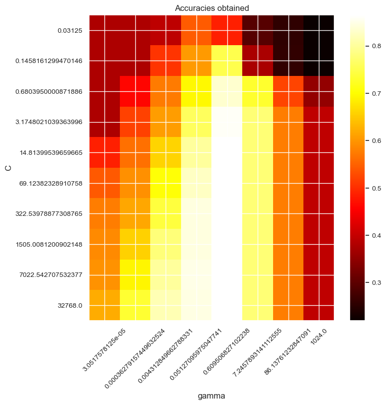

```python
vector_scores = grid_search_cv_svm.cv_results_.get('mean_test_score')
grid_scores = np.reshape(vector_scores, (len(Cs), len(gammas)))

# New accuracies
plt.imshow(grid_scores, interpolation='nearest', cmap=plt.cm.hot)
plt.xlabel('gamma')
plt.ylabel('C')
plt.colorbar().ax.tick_params(labelsize=10)
plt.xticks(np.arange(len(gammas)), gammas, rotation=45, fontsize=10)
plt.yticks(np.arange(len(Cs)), Cs, fontsize=10)
plt.title('Accuracies obtained')
plt.show()
```

#### Accuracies

```python
# Recover these variables from GridSearchCV object
best_model = grid_search_cv_svm.best_estimator_
best_acc = grid_search_cv_svm.best_score_
best_C = grid_search_cv_svm.best_params_['svc__C']
best_gamma = grid_search_cv_svm.best_params_['svc__gamma']
```

```python
print("Best C = " + str(best_C))
print("Best gamma = " + str(best_gamma))
print("Best accuracy on train = " + str(best_acc))
print('Best accuracy on test = ' + str(best_model.score(X_test, y_test)))
```

```
Best C = 322.53978877308765
Best gamma = 0.609506827102238
Best accuracy on train = 0.8656644702642708
Best accuracy on test = 0.8740831295843521
```

#### More performance metrics

```python
y_hat = grid_search_cv_svm.predict(X_test)
performance_metrics = classification_report(y_true=y_test, y_pred=y_hat)
print(performance_metrics)
```

```
              precision    recall  f1-score   support

           3       0.98      1.00      0.99       137
           4       0.94      0.99      0.97       136
           5       0.74      0.72      0.73       137
           6       0.70      0.65      0.67       136
           7       0.89      0.89      0.89       136
           8       0.96      1.00      0.98       136

    accuracy                           0.87       818
   macro avg       0.87      0.87      0.87       818
weighted avg       0.87      0.87      0.87       818
```

#### Confusion matrix

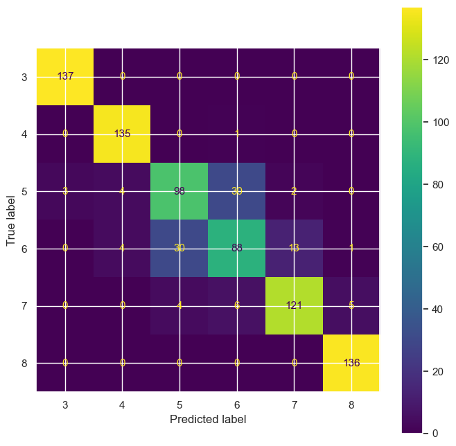

```python
from sklearn.metrics import confusion_matrix, ConfusionMatrixDisplay

y_pred = grid_search_cv_svm.predict(X_test)
confusion_matrix_svm = confusion_matrix(y_true=y_test, y_pred=y_pred, labels=grid_search_cv_svm.classes_)
confusion_matrix_display_svm = ConfusionMatrixDisplay(confusion_matrix=confusion_matrix_svm, display_labels=grid_search_cv_svm.classes_)
confusion_matrix_display_svm.plot()
for text in confusion_matrix_display_svm.text_.ravel():
    text.set_fontsize(11)
```

### Pipeline: k-NN

#### Training

```python
param_grid_knn = {'knn__n_neighbors':[1,3,5,7,9,11,13],
              'knn__weights':['uniform', 'distance'],
              'knn__p':[2,3,4,5]}

# Normalization (mean zero, unit variance) provides numerical stability during grid search
pipeline_knn = Pipeline(steps=[('scaler', StandardScaler()), ('knn', KNeighborsClassifier(n_jobs=4))])

grid_search_cv_knn = GridSearchCV(estimator=pipeline_knn,
                      param_grid=param_grid_knn,
                      scoring='accuracy',
                      cv=5, verbose=1, n_jobs=8) # 5-fold stratified CV

grid_search_cv_knn.fit(X_train, y_train)
```

```
Fitting 5 folds for each of 56 candidates, totalling 280 fits
```

```
GridSearchCV(cv=5,
             estimator=Pipeline(steps=[('scaler', StandardScaler()),
                                       ('knn',
                                        KNeighborsClassifier(n_jobs=4))]),
             n_jobs=8,
             param_grid={'knn__n_neighbors': [1, 3, 5, 7, 9, 11, 13],
                         'knn__p': [2, 3, 4, 5],
                         'knn__weights': ['uniform', 'distance']},
             scoring='accuracy', verbose=1)
```

#### Accuracies

```python
print('Best parameters=', grid_search_cv_knn.best_params_)
print('Best accuracy on train=', grid_search_cv_knn.best_score_)
print('Best accuracy on test=', grid_search_cv_knn.score(X_test, y_test))
```

```
Best parameters= {'knn__n_neighbors': 1, 'knn__p': 2, 'knn__weights': 'uniform'}
Best accuracy on train= 0.8503669256454567
Best accuracy on test= 0.8545232273838631
```

#### More performance metrics

```python
y_hat_knn = grid_search_cv_knn.predict(X_test)
performance_metrics_knn = classification_report(y_true=y_test, y_pred=y_hat_knn)
print(performance_metrics_knn)
```

```
              precision    recall  f1-score   support

           3       0.96      1.00      0.98       137
           4       0.86      0.98      0.92       136
           5       0.78      0.64      0.70       137
           6       0.69      0.59      0.63       136
           7       0.84      0.92      0.88       136
           8       0.94      1.00      0.97       136

    accuracy                           0.85       818
   macro avg       0.85      0.85      0.85       818
weighted avg       0.85      0.85      0.85       818
```

#### Confusion matrix

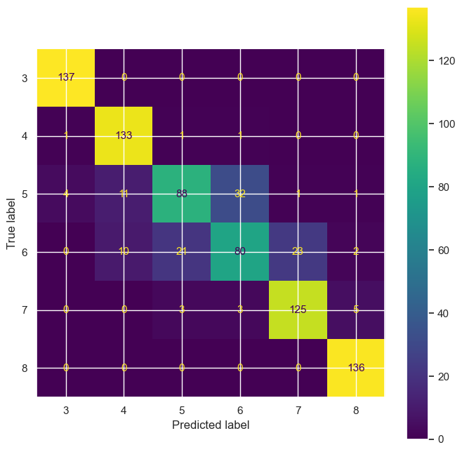

```python
from sklearn.metrics import confusion_matrix, ConfusionMatrixDisplay
y_pred_knn = grid_search_cv_knn.predict(X_test)
confusion_matrix_knn = confusion_matrix(y_true=y_test, y_pred=y_pred_knn, labels=grid_search_cv_knn.classes_)
confusion_matrix_display_knn = ConfusionMatrixDisplay(confusion_matrix=confusion_matrix_knn, display_labels=grid_search_cv_knn.classes_)
confusion_matrix_display_knn.plot()
for text in confusion_matrix_display_knn.text_.ravel():
    text.set_fontsize(11)
```

### Pipeline: Random Forest

#### Training

```python
pipeline_random_forest = Pipeline(steps=[('scaler', StandardScaler()), ('random_forest_classifier', RandomForestClassifier(n_estimators=200))])
pipeline_random_forest.fit(X_train, y_train)
```

```
Pipeline(steps=[('scaler', StandardScaler()),
                ('random_forest_classifier',
                 RandomForestClassifier(n_estimators=200))])
```

#### Accuracies

```python
acc_train = pipeline_random_forest.score(X_train, y_train)
acc_test = pipeline_random_forest.score(X_test, y_test)
print('Accuracy on train=', acc_train)
print('Accuracy on test=', acc_test)
```

```
Accuracy on train= 1.0
Accuracy on test= 0.871638141809291
```

#### More performance metrics

```python
pred_random_forest_classifier = pipeline_random_forest.predict(X_test)
print(classification_report(y_true=y_test, y_pred=pred_random_forest_classifier))
```

```
              precision    recall  f1-score   support

           3       0.98      1.00      0.99       137
           4       0.90      0.98      0.94       136
           5       0.78      0.69      0.73       137
           6       0.71      0.65      0.68       136
           7       0.87      0.90      0.88       136
           8       0.96      1.00      0.98       136

    accuracy                           0.87       818
   macro avg       0.87      0.87      0.87       818
weighted avg       0.87      0.87      0.87       818
```

#### Confusion matrix

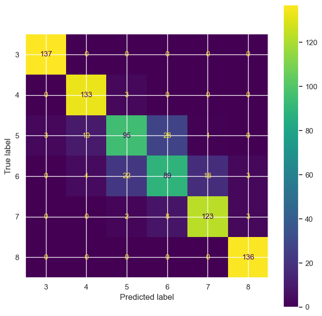

```python
from sklearn.metrics import confusion_matrix, ConfusionMatrixDisplay
y_pred_rfc = pipeline_random_forest.predict(X_test)
confusion_matrix_rfc = confusion_matrix(y_true=y_test, y_pred=y_pred_rfc, labels=pipeline_random_forest.classes_)
confusion_matrix_display_rfc = ConfusionMatrixDisplay(confusion_matrix=confusion_matrix_rfc, display_labels=pipeline_random_forest.classes_)
confusion_matrix_display_rfc.plot()
for text in confusion_matrix_display_rfc.text_.ravel():
    text.set_fontsize(11)
```

## Table of accuracies

The table below shows accuracies (acc_train, acc_test) on the unbalanced dataset and on the balanced one (with *_smote* appended).

[output not shown]

## Summary and conclusions

In this notebook we have used the Wine Quality dataset to study the behaviour of an unbalanced dataset on final accuracy. We have plotted the frequency distributions of all features and we have measured the skewness and kurtosis of all of them. We have learned that the skewness indicates the direction of the outliers, and kurtosis talks about the number of outliers. Then we trained three different classifiers and it turned out the accuracy was stucked at roughly 67 %.

To solve the situation, we used SMOTE technique, which uses k-nearest neighbors algorithm, to populate only those under-represented classes in the dataset. The result was a new dataset having all classes equally and uniformly represented. We re-train out set of classifiers and we obtained better accuracies on the balanced dataset.